# Student Alcohol Consumption Analysis

# Multiple Variable Plots

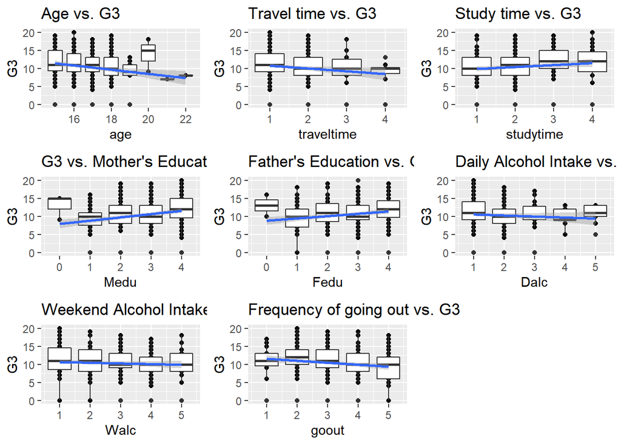

```r
#Checking Predictor Variables vs. Target Variables


f1 <- ggplot(data, aes(x=age, y=G3, group = age)) + geom_point() + geom_boxplot() + geom_smooth(method = "lm", aes(group = 1)) + ggtitle("Age vs. G3")
f2 <- ggplot(data, aes(x=traveltime, y=G3, group = traveltime)) + geom_point() + geom_boxplot() +  geom_smooth(method = "lm", aes(group = 1)) +ggtitle("Travel time vs. G3")
f3 <- ggplot(data, aes(x=studytime, y=G3, group = studytime)) + geom_point() + geom_boxplot() + geom_smooth(method = "lm", aes(group = 1)) + ggtitle("Study time vs. G3")
f6 <- ggplot(data, aes(x=Medu, y=G3, group = Medu)) + geom_point() + geom_boxplot() + geom_smooth(method = "lm", aes(group = 1)) + ggtitle("G3 vs. Mother's Education")
f7 <- ggplot(data, aes(x=Fedu, y=G3, group = Fedu)) + geom_point() + geom_boxplot() + geom_smooth(method = "lm", aes(group = 1)) + ggtitle("Father's Education vs. G3")
f8 <- ggplot(data, aes(x=Dalc, y=G3, group = Dalc)) + geom_point() + geom_boxplot() + geom_smooth(method = "lm", aes(group = 1)) + ggtitle("Daily Alcohol Intake vs. G3")
f9 <- ggplot(data, aes(x=Walc, y=G3, group = Walc)) + geom_point() + geom_boxplot() + geom_smooth(method = "lm", aes(group = 1)) + ggtitle("Weekend Alcohol Intake vs. G3")
f14 <- ggplot(data, aes(x=goout, y=G3, group = goout))+ geom_point() +  geom_boxplot() + geom_smooth(method = "lm", aes(group = 1)) +  ggtitle("Frequency of going out vs. G3")

grid.arrange(f1, f2, f3, f6, f7, f8, f9, f14, nrow=3)
```

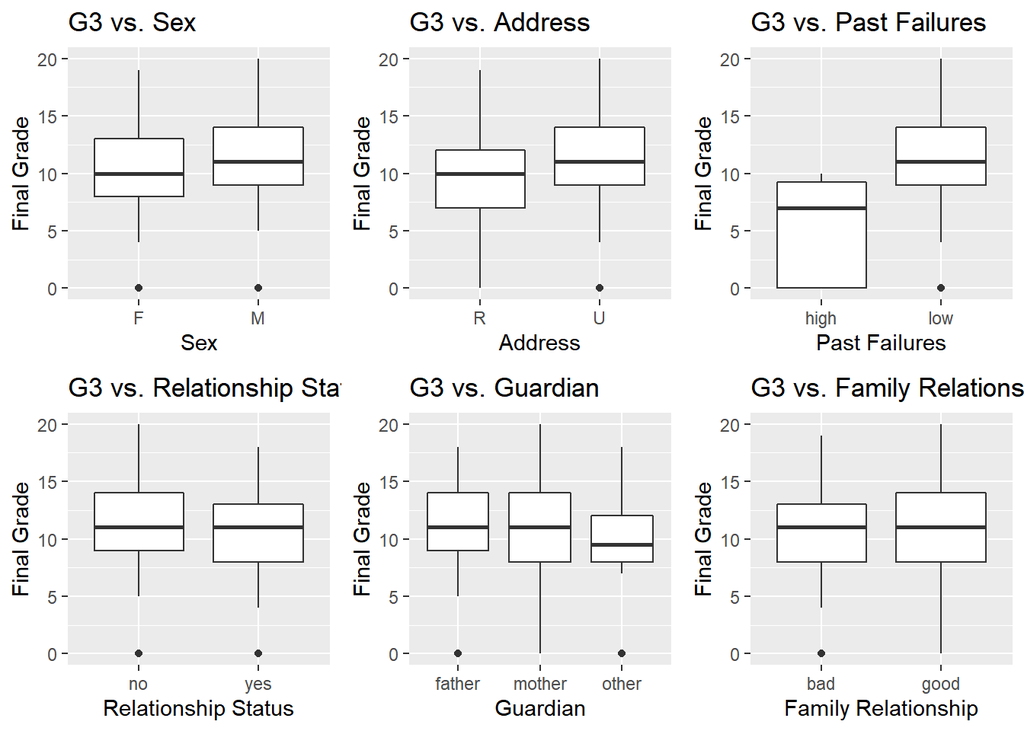

```r
f4 <- ggplot(data, aes(x=sex, y= G3))+ geom_boxplot()+ xlab("Sex")+ ylab("Final Grade")+ ggtitle("G3 vs. Sex")
f5 <- ggplot(data, aes(x=address, y= G3))+ geom_boxplot()+ xlab("Address")+ ylab("Final Grade")+ ggtitle("G3 vs. Address")
f10 <- ggplot(data, aes(x=failures, y= G3, group = failures))+ geom_boxplot()+ xlab("Past Failures")+ ylab("Final Grade")+ ggtitle("G3 vs. Past Failures")
f11 <- ggplot(data, aes(x=romantic, y= G3))+ geom_boxplot()+ xlab("Relationship Status")+ ylab("Final Grade")+ ggtitle("G3 vs. Relationship Status")
f12 <- ggplot(data, aes(x=guardian, y= G3))+ geom_boxplot()+ xlab("Guardian")+ ylab("Final Grade")+ ggtitle("G3 vs. Guardian")
f13 <- ggplot(data, aes(x=famrel, y= G3, group = famrel))+ geom_boxplot()+ xlab("Family Relationship")+ ylab("Final Grade")+ ggtitle("G3 vs. Family Relationship")



grid.arrange(f4, f5, f10, f11, f12, f13, nrow = 2)
```

*The plots above showed pretty good observations. We can understand that with an increase in travel time, alcohol consumption, be it weekday or weekend, frequency of going out and age, there is a decrease in the final grade of the students. The age factor is strange and interesting too. This particular insight is against general fact that students study better as they grow older. Well, the extent of this being true is unknown!!*

Also, an obvious insight is that with an increase in study time, parent’s education, there is an observed increase in final grade.

## Exploratory Data Analysis

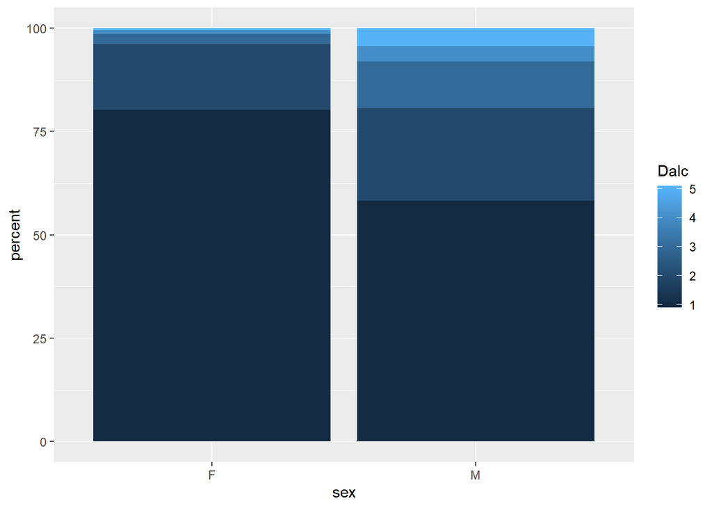

```r
#Alcohol Consumption among male and female during Weekdays

temp <- data %>% group_by(sex,Dalc) %>% summarise(n=n())

ce <- ddply(temp, "sex", transform,
percent = n / sum(n) * 100)
ggplot(ce, aes(x=sex, y=percent, fill=Dalc)) +
geom_bar(stat="identity")
```

**From the plot, we can infer that 80% of the girls had low weekday alcohol consumption rate compared to boys.**

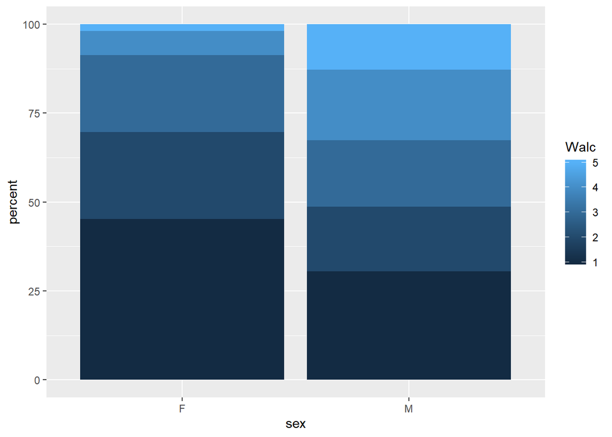

```r
#Alcohol Consumption among male and female during Weekends

temp <- data %>% group_by(sex,Walc) %>% summarise(n=n())
#temp$Walc <- as.factor(temp$Walc)

ce <- ddply(temp, "sex", transform,
percent = n / sum(n) * 100)
ggplot(ce, aes(x=sex, y=percent, fill=Walc)) +
geom_bar(stat="identity")
```

**Meanwhile looking at weekend alcohol consumption rate, it can be inferred that alcohol consumption was relatively double as that on a weekday.**

**These plots prove the myth to be absoolutely right!! Girls indeed drink a lot less than all the boys out there! Good to know ain’t it?**

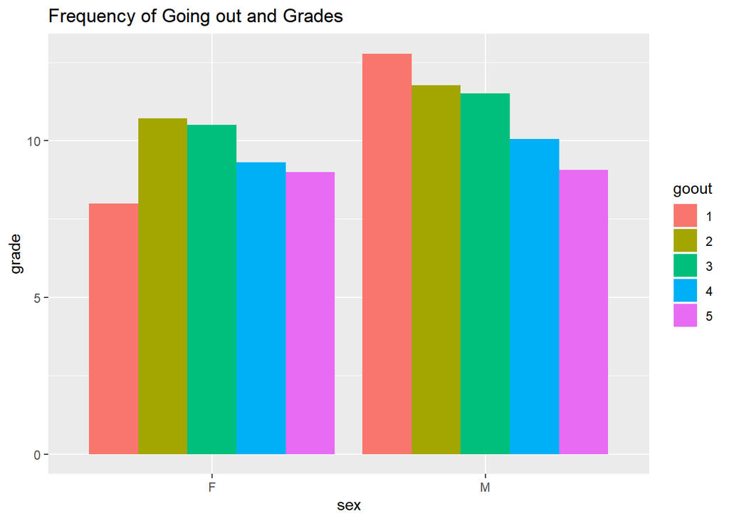

```r
#Frequency of going out and Final grades

data %>% mutate(avg_grade=G3,goout=as.factor(goout)) %>% group_by(goout,sex) %>% summarise(grade=mean(avg_grade)) %>%
  ggplot(aes(x=sex,y=grade,fill=goout))+geom_bar(stat="identity",position = "dodge")+ggtitle("Frequency of Going out and Grades")
```

**The plot above shows us that on a whole, boys go out frequently than girls and also, boys who rarely roam around have a better grade than girls in the same category.**

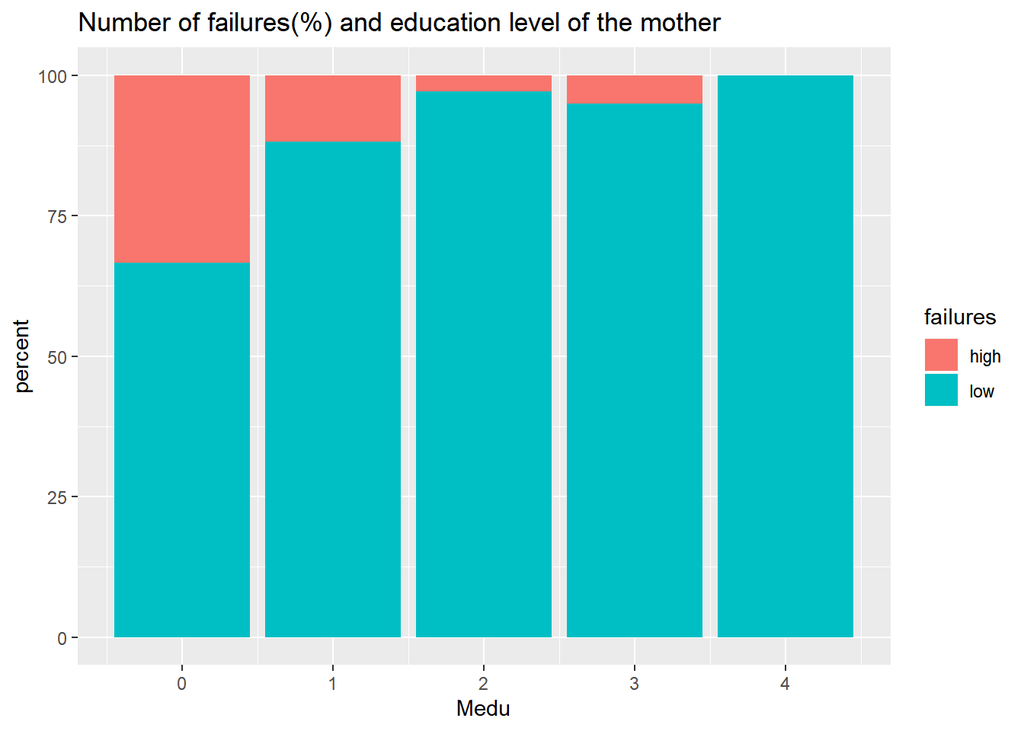

```r
data %>% mutate(failures=as.factor(failures))%>% group_by(Medu,failures) %>% summarise(n=n()) %>%
  ddply("Medu",transform,percent=n/sum(n)*100) %>%
  ggplot(aes(x=Medu,y=percent,fill=failures))+
  geom_bar(stat="identity")+ggtitle("Number of failures(%) and education level of the mother")
```

**This plot is pretty interesting on how the student failures is related to mother’s education level. An obvious and clear conclusion is that, if a mother holds a higher degree, then there would be no failures or there would be a very low scope of student failures.**

# Modeling

## Linear Regression

Our final linear model is built over the final grade, G3, and all the other influencing variables in the transformed dataset.

```r
#Scaling the outcome variable
data$G3 <- scale(data$G3) [, 1]

#Applying Linear Regression to predict Final Grade
model <- lm(data$G3 ~., data=data)
summary(model)
```

```
##
## Call:
## lm(formula = data$G3 ~ ., data = data)
##
## Residuals:
##      Min       1Q   Median       3Q      Max
## -3.03723 -0.43002  0.08874  0.61091  1.95054
##
## Coefficients:
##                  Estimate Std. Error t value Pr(>|t|)
## (Intercept)    -0.4490279  0.8283961  -0.542  0.58811
## age            -0.0457652  0.0427949  -1.069  0.28557
## traveltime     -0.0609002  0.0741208  -0.822  0.41180
## studytime       0.1260322  0.0618722   2.037  0.04235 *
## Medu            0.1463740  0.0581685   2.516  0.01227 *
## Fedu            0.0006454  0.0580015   0.011  0.99113
## Dalc           -0.0501969  0.0713043  -0.704  0.48188
## Walc            0.0606357  0.0535810   1.132  0.25849
## sexM            0.2469225  0.1046563   2.359  0.01881 *
## addressU        0.1887595  0.1254669   1.504  0.13330
## failureslow     0.7475231  0.2538333   2.945  0.00343 **
## romanticyes    -0.2465766  0.1029139  -2.396  0.01706 *
## goout          -0.1320042  0.0487351  -2.709  0.00706 **
## famrelgood      0.1076778  0.1139279   0.945  0.34519
## guardianmother  0.0140835  0.1190021   0.118  0.90586
## guardianother  -0.0457455  0.2130384  -0.215  0.83009
## ---
## Signif. codes:  0 '***' 0.001 '**' 0.01 '*' 0.05 '.' 0.1 ' ' 1
##
## Residual standard error: 0.9409 on 379 degrees of freedom
## Multiple R-squared:  0.1483, Adjusted R-squared:  0.1146
## F-statistic:   4.4 on 15 and 379 DF,  p-value: 1.197e-07
```

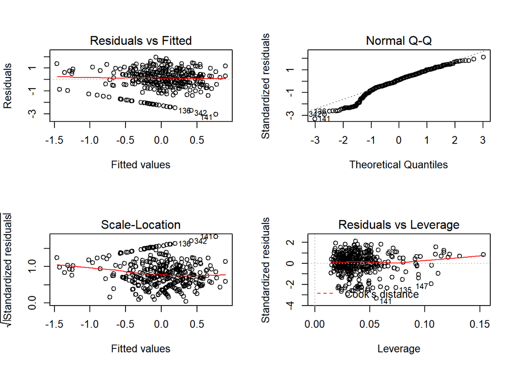

```r
#Creating residual plots
layout(matrix(1:4,2,2))
par(mfrow=c(2,2))
plot(model)
```

The regression coefficients show us that, mother’s education, low failures, male gender and living in urban areas, are crucial for a good final grade. With a unit change in mother’s education and failures, there would be 0.15 and 0.75 unit change in G3. With a unit change in sex-M and Address-U, there would be 0.25 and 0.19 unit change in G3. As discussed earlier, travel time, age, daily alcohol consumption, active relationship, frequently going out and having another guardian apart from the mother, would result in a decrease in the final grade or G3. *Strangely, weekend alcohol consumption rate is given a very low positive relationsip. This means that with every unit change in Walc, there is 0.06 increase in grade G3. This is one result that is generally not expected, be it due to any reasons possible!*

# Conclusion

- Our basic goal was to find major factors that influenced the final grade of the students. We found that Medu, Failures-low, Sex-Male, and Address-Urban drove good grades.
- We also pulled out many interesting insights about how staying a relationship affected grades, which population (male or female) had higher alcohol intake, and also about the extent of mother’s education and family relationships influencing the student’s final grade.
- My major challenge was to clean the data and to narrow the analysis towards the right variables. Hopefully, I could draw convincingly good insights.
- Given more time, I could project an elaborative study over how alcohol consumption affected grades among various age groups. Such results would be great to know!